# Danish Monarchs

Astrid Hannestad

2025-03-07

The task here is to load your Danish Monarchs csv into R using the `tidyverse` toolkit, calculate and explore the kings’ duration of reign with pipes `%>%` in `dplyr` and plot it over time.

## Load the kings

Make sure to first create an `.Rproj` workspace with a `data/` folder where you place either your own dataset or the provided `kings.csv` dataset.

1. Look at the dataset that are you loading and check what its columns are separated by? (hint: open it in plain text editor to see)

List what is the

separator: ;

2. Create a `kings` object in R with the different functions below and inspect the different outputs.
- `read.csv()`
- `read_csv()`
- `read.csv2()`
- `read_csv2()`

```r
# FILL IN THE CODE BELOW and review the outputs
library(tidyverse)
kings1 <- read.csv("data/Kongeraekken-csv.csv")

kings2 <- read_csv("data/Kongeraekken-csv.csv")
kings3 <- read.csv2("data/Kongeraekken-csv.csv")

kings4 <- read_csv2( "data/Kongeraekken-csv.csv")
```

```
## ℹ Using "','" as decimal and "'.'" as grouping mark. Use `read_delim()` for more control.
```

Answer: 1. Which of these functions is a `tidyverse` function? Read data with it below into a `kings` object - Read_csv and read_csv2 2. What is the result of running `class()` on the `kings` object created with a tidyverse function. - it shows that it’s a tibble data frame 3. How many columns does the object have when created with these different functions? - For nr 1 and 2 it shows only one column, because they are made for comma seperated csv files, and for 3 and 4 it shows 5 because they are made for semicolon seperated files, which mine is 4. Show the dataset so that we can see how R interprets each column

```r
# COMPLETE THE BLANKS BELOW WITH YOUR CODE, then turn the 'eval' flag in this chunk to TRUE.


class(kings1)
```

```
## [1] "data.frame"
```

```r
class(kings2)
```

```
## [1] "spec_tbl_df" "tbl_df"      "tbl"         "data.frame"
```

```r
class(kings3)
```

```
## [1] "data.frame"
```

```r
class(kings4)
```

```
## [1] "spec_tbl_df" "tbl_df"      "tbl"         "data.frame"
```

```r
ncol(kings1)
```

```
## [1] 1
```

```r
ncol(kings2)
```

```
## [1] 1
```

```r
ncol(kings3)
```

```
## [1] 5
```

```r
ncol(kings4)
```

```
## [1] 5
```

```r
head(kings1)
```

```
##   Monarch.Birth_year.Beginning_reign_year.End_reign_year.Death_year
## 1                                     Gorm_den_gamle;NA;936;958;958
## 2                                  Harald_1_blaatand;NA;958;987;987
## 3                                 Svend_1_Tveskaeg;NA;987;1014;1014
## 4                                        Harald_2;NA;1014;1018;1018
## 5                               Knud_1_den_store;995;1018;1035;1035
## 6                                     Hardeknud;1020;1035;1042;1042
```

```r
head(kings2)
```

```
## # A tibble: 6 × 1
##   `Monarch;Birth_year;Beginning_reign_year;End_reign_year;Death_year`
##   <chr>
## 1 Gorm_den_gamle;NA;936;958;958
## 2 Harald_1_blaatand;NA;958;987;987
## 3 Svend_1_Tveskaeg;NA;987;1014;1014
## 4 Harald_2;NA;1014;1018;1018
## 5 Knud_1_den_store;995;1018;1035;1035
## 6 Hardeknud;1020;1035;1042;1042
```

```r
head(kings3)
```

```
##             Monarch Birth_year Beginning_reign_year End_reign_year Death_year
## 1    Gorm_den_gamle         NA                  936            958        958
## 2 Harald_1_blaatand         NA                  958            987        987
## 3  Svend_1_Tveskaeg         NA                  987           1014       1014
## 4          Harald_2         NA                 1014           1018       1018
## 5  Knud_1_den_store        995                 1018           1035       1035
## 6         Hardeknud       1020                 1035           1042       1042
```

```r
head(kings4)
```

```
## # A tibble: 6 × 5
##   Monarch           Birth_year Beginning_reign_year End_reign_year Death_year
##   <chr>                  <dbl>                <dbl>          <dbl>      <dbl>
## 1 Gorm_den_gamle            NA                  936            958        958
## 2 Harald_1_blaatand         NA                  958            987        987
## 3 Svend_1_Tveskaeg          NA                  987           1014       1014
## 4 Harald_2                  NA                 1014           1018       1018
## 5 Knud_1_den_store         995                 1018           1035       1035
## 6 Hardeknud               1020                 1035           1042       1042
```

```r
kings <- read_csv2( "data/Kongeraekken-csv.csv")
```

```
## ℹ Using "','" as decimal and "'.'" as grouping mark. Use `read_delim()` for more control.
```

## Calculate the duration of reign for all the kings in your table

You can calculate the duration of reign in years with `mutate` function by subtracting the equivalents of your `startReign` from `endReign` columns and writing the result to a new column called `duration`. But first you need to check a few things:

- Is your data messy? Fix it before re-importing to R
- Do your start and end of reign columns contain NAs? Choose the right strategy to deal with them: `na.omit()`, `na.rm=TRUE`, `!is.na()`

Create a new column called `duration` in the kings dataset, utilizing the `mutate()` function from tidyverse. Check with your group to brainstorm the options.

```r
kings <- kings %>%
  mutate(reign_duration = End_reign_year - Beginning_reign_year) %>%
  mutate(midyear = Beginning_reign_year + reign_duration/2)
```

## Calculate the average duration of reign for all rulers

Do you remember how to calculate an average on a vector object? If not, review the last two lessons and remember that a column is basically a vector. So you need to subset your `kings` dataset to the `duration` column. If you subset it as a vector you can calculate average on it with `mean()` base-R function. If you subset it as a tibble, you can calculate average on it with `summarize()` tidyverse function. Try both ways! %>%

- You first need to know how to select the relevant `duration` column. What are your options?
- Is your selected `duration` column a tibble or a vector? The `mean()` function can only be run on a vector. The `summarize()` function works on a tibble.
- Are you getting an error that there are characters in your column? Coerce your data to numbers with `as.numeric()`.
- Remember to handle NAs: `mean(X, na.rm=TRUE)`

```r
kings %>%
  summarize(average = mean(reign_duration, na.rm = TRUE))
```

```
## # A tibble: 1 × 1
##   average
##     <dbl>
## 1    20.2
```

## How many and which kings enjoyed a longer-than-average duration of reign?

You have calculated the average duration above. Use it now to `filter()` the `duration` column in `kings` dataset. Display the result and also count the resulting rows with `count()`

```r
kings %>%
  filter(reign_duration > 20.2)
```

```
## # A tibble: 26 × 7
##    Monarch             Birth_year Beginning_reign_year End_reign_year Death_year
##    <chr>                    <dbl>                <dbl>          <dbl>      <dbl>
##  1 Gorm_den_gamle              NA                  936            958        958
##  2 Harald_1_blaatand           NA                  958            987        987
##  3 Svend_1_Tveskaeg            NA                  987           1014       1014
##  4 Svend_2_Estridsen           NA                 1047           1074       1076
##  5 Niels                       NA                 1104           1134       1134
##  6 Valdemar_1_den_sto…       1131                 1157           1182       1182
##  7 Valdemar_2_sejr           1170                 1202           1241       1241
##  8 Erik_5_Klipping           1249                 1259           1286       1286
##  9 Erik_6_Menved             1274                 1286           1319       1319
## 10 Valdemar_4_Atterdag       1320                 1340           1375       1375
## # ℹ 16 more rows
## # ℹ 2 more variables: reign_duration <dbl>, midyear <dbl>
```

## How many days did the three longest-ruling monarchs rule?

- Sort kings by reign `duration` in the descending order. Select the three longest-ruling monarchs with the `slice()` function
- Use `mutate()` to create `Days` column where you calculate the total number of days they ruled
- BONUS: consider the transition year (with 366 days) in your calculation!

```r
kings %>%
  arrange(desc(reign_duration)) %>%
  slice(1:3) %>%
  mutate(Days = reign_duration * 365 + floor(reign_duration/4)) %>%
  select(Monarch, reign_duration, Days)
```

```
## # A tibble: 3 × 3
##   Monarch     reign_duration  Days
##   <chr>                <dbl> <dbl>
## 1 Christian_4             60 21915
## 2 Margrethe_2             52 18993
## 3 Christian_9             43 15705
```

## Challenge: Plot the kings’ duration of reign through time

What is the long-term trend in the duration of reign among Danish monarchs? How does it relate to the historical violence trends ? It shows that the longer up in time, the longer monarchs live. When the middle ages begin there is a dip in the duration of the reigns, and towards the 1500s and onwards they begin to reign longer and longer, as the monarchy becomes more stable.

- Try to plot the duration of reign column in `ggplot` with `geom_point()` and `geom_smooth()`
- In order to peg the duration (which is between 1-99) somewhere to the x axis with individual centuries, I recommend creating a new column `midyear` by adding to `startYear` the product of `endYear` minus the `startYear` divided by two (`startYear + (endYear-startYear)/2`).
- Now you can plot the kings dataset, plotting `midyear` along the x axis and `duration` along y axis
- BONUS: add a title, nice axis labels to the plot and make the theme B&W and font bigger to make it nice and legible!

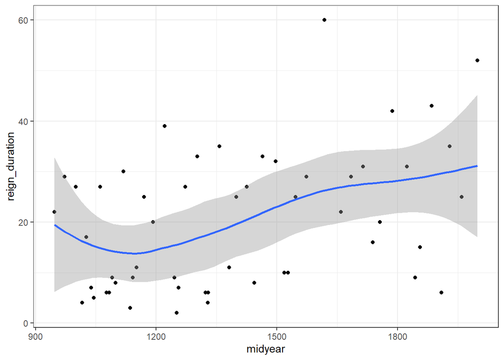

```r
kings %>%
  filter(!is.na(reign_duration)) %>%
  ggplot(aes(x=midyear, y=reign_duration)) +
  geom_point()+
  geom_smooth()+
  theme_bw()
```

And to submit this rmarkdown, knit it into html. But first, clean up the code chunks, adjust the date, rename the author and change the `eval=FALSE` flag to `eval=TRUE` so your script actually generates an output. Well done!